# Rreverse_engineering_project

*Here is that code:*

```r
yearly_total_mlb <- clean_sports_pol_donations |>
  group_by(election_year, party, league) |>
  filter(str_detect(league, "MLB")) |>
  summarise(total = sum(amount)) |>
  group_by(election_year) |>
  summarise(yearly_total = sum(total))

yearly_total_nascar <- clean_sports_pol_donations |>
  group_by(election_year, party, league) |>
  filter(str_detect(league, "NASCAR")) |>
  summarise(total = sum(amount)) |>
  group_by(election_year) |>
  summarise(yearly_total = sum(total))

yearly_total_nba <- clean_sports_pol_donations |>
  group_by(election_year, party, league) |>
  filter(str_detect(league, "NBA") & league != "MLB, WNBA" & league != "WNBA") |>
  summarise(total = sum(amount)) |>
  group_by(election_year) |>
  summarise(yearly_total = sum(total))

yearly_total_nfl <- clean_sports_pol_donations |>
  group_by(election_year, party, league) |>
  filter(str_detect(league, "NFL")) |>
  summarise(total = sum(amount)) |>
  group_by(election_year) |>
  summarise(yearly_total = sum(total))

yearly_total_nhl <- clean_sports_pol_donations |>
  group_by(election_year, party, league) |>
  filter(str_detect(league, "NHL")) |>
  summarise(total = sum(amount)) |>
  group_by(election_year) |>
  summarise(yearly_total = sum(total))

yearly_total_wnba <- clean_sports_pol_donations |>
  group_by(election_year, party, league) |>
  filter(str_detect(league, "WNBA")) |>
  summarise(total = sum(amount)) |>
  group_by(election_year) |>
  summarise(yearly_total = sum(total))
```

*In this next step, we’re merging the two data frames we’ve made for each league by election year and then mutating to add a column calculating the percentage distribution of political donations by party. To calculate those percentages, we’re dividing the total number of donations by party from the combined total of all donations made in a specific election year.*

*Here is that code:*

```r
mlb_percents <- merge(mlb_contributions, yearly_total_mlb, by = "election_year") |>
mutate (percents = total/yearly_total*100)

nascar_percents <- merge(nascar_contributions, yearly_total_nascar, by = "election_year") |>
mutate (percents = total/yearly_total*100)

nba_percents <- merge(nba_contributions, yearly_total_nba, by = "election_year") |>
mutate (percents = total/yearly_total*100)

nfl_percents <- merge(nfl_contributions, yearly_total_nfl, by = "election_year") |>
mutate (percents = total/yearly_total*100)

nhl_percents <- merge(nhl_contributions, yearly_total_nhl, by = "election_year") |>
mutate (percents = total/yearly_total*100)

wnba_percents <- merge(wnba_contributions, yearly_total_wnba, by = "election_year") |>
mutate (percents = total/yearly_total*100)
```

*Now that we’ve calculated our percentages, we’ll use the ggplot function to create stacked bar charts for each league that visualize the donation breakdown. Our x-axis represents election years and our y-axis represents the percentage of donations contributed. The position portion of the second line of code enables us to create a stacked bar chart. The stat = identity portion means that the heights of each bar represent values of the percentages in our data. We’ll then assign the correct colors for each party with scale_fill_manual and then review our stacked bar charts to see that they match what’s shown in the article.*

```r
ggplot(mlb_percents, aes(fill=party, y=percents, x=election_year)) +
    geom_bar(position="stack", stat="identity") +
    scale_fill_manual(values=c('blue', 'red'))
```

[output not shown]

```r
ggplot(nascar_percents, aes(fill=party, y=percents, x=election_year)) +
    geom_bar(position="stack", stat="identity") +
    scale_fill_manual(values=c('blue', 'red'))
```

[output not shown]

```r
ggplot(nba_percents, aes(fill=party, y=percents, x=election_year)) +
    geom_bar(position="stack", stat="identity") +
    scale_fill_manual(values=c('blue', 'red'))
```

[output not shown]

```r
ggplot(nfl_percents, aes(fill=party, y=percents, x=election_year)) +
    geom_bar(position="stack", stat="identity") +
    scale_fill_manual(values=c('blue', 'red'))
```

[output not shown]

```r
ggplot(nhl_percents, aes(fill=party, y=percents, x=election_year)) +
    geom_bar(position="stack", stat="identity") +
    scale_fill_manual(values=c('blue', 'red'))
```

[output not shown]

```r
ggplot(wnba_percents, aes(fill=party, y=percents, x=election_year)) +
    geom_bar(position="stack", stat="identity") +
    scale_fill_manual(values=c('blue', 'red'))
```

[output not shown]

“There are 40 owners who have donated at least $100,000 to Republican causes over the six-year period, compared to 23 owners topping $100,000 to Democrats, helping lead to these splits: Team owners give largely to the GOP. Share of donations from team owners in six leagues, per year and per party.”

*#5: For our last example, we created a stacked bar chart showing the percentage of political contributions by party in each election year. We started by creating a data frame from our original data frame that groups the data by election year and summarizes with a column that takes the total amount of money donated in each specific election year.*

```r
donations_by_year <- clean_sports_pol_donations |>
  group_by(election_year) |>
    summarise(total_amount=sum(amount)) |>
    arrange(desc(total_amount))
```

*Then we created another data frame that shows the total amount of donations by party for each specific election year. We accomplished this by grouping the data by election year and party, filtering by each individual party and summarizing by adding the donation amounts.*

```r
election_year_totals <-
clean_sports_pol_donations |>
  group_by(election_year, party) |>
   filter(party == "Republican" | party == "Democrat") |>
  summarise(total = sum(amount))
```

*The next step was to merge the data frames we just created into one data frame based on election year. We renamed the “total” columns to clarify which was one the entire total for the year and the party’s total.*

```r
total_by_year <- merge(donations_by_year, election_year_totals, by = "election_year") |>
  rename(year_total = "total_amount", party_total = "total")
```

*We took the merged data frame and mutated to add a new column calculating the percentage of donations each party received from owners in a specific election year. To do this we divided the party total from the year total and multiplied by 100.*

```r
total_by_year <- total_by_year |>
  mutate(percents = party_total/year_total*100)
```

*Finally, much like in another example shown above, we created our stacked bar chart using the ggplot function. Here is the final product:*

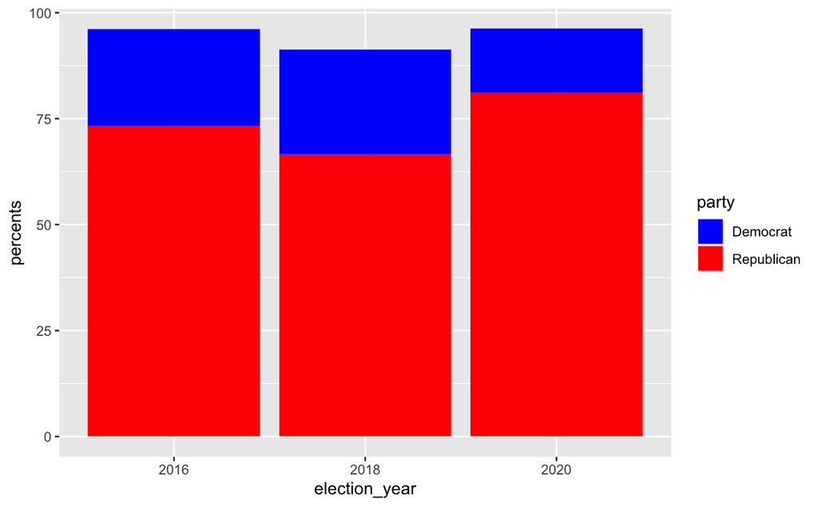

```r
ggplot(total_by_year, aes(fill=party, y=percents, x=election_year)) +
    geom_bar(position="stack", stat="identity") +
    scale_fill_manual(values=c('blue', 'red'))
```